# 8k PBMC Example

Won-Min Song

2024-12-13

#### MSC workflow Vignette with 8k PBMC data set

This is a MSC workflow vignette using 8k PBMC single-cell RNA-seq data. The raw count data can be downloaded NF from Data Portal and on Synpase with DOI, https://doi.org/10.7303/syn52966803, under ‘8k_PBMC_10x_Counts’ folder. The downloaded data should be placed under folder named “Data”, rooted on the working directory of choice. To save time, the processed data can also be downloaded from the same [DOI link](https://doi.org/10.7303/syn52966803) in ‘8k_PBMC_Processed’ folder, and should be placed under the working directory. This will bypass from [Section 1](http://localhost:8787/file_show?path=%2Ftmp%2FRtmp1BZpvj%2Fpreview-23f64d46e924.dir%2F8k_PBMC_workflow.html#S1) to [Section 2](http://localhost:8787/file_show?path=%2Ftmp%2FRtmp1BZpvj%2Fpreview-23f64d46e924.dir%2F8k_PBMC_workflow.html#S2).

Overall, the vignette is organized as follows:  
[Section 1. Pre-processing](http://localhost:8787/file_show?path=%2Ftmp%2FRtmp1BZpvj%2Fpreview-23f64d46e924.dir%2F8k_PBMC_workflow.html#S1);  
[Section 2. Cell type annotations using SingleR](http://localhost:8787/file_show?path=%2Ftmp%2FRtmp1BZpvj%2Fpreview-23f64d46e924.dir%2F8k_PBMC_workflow.html#S2);  
[Section 3. MSC workflow: Pearson’s correlation](http://localhost:8787/file_show?path=%2Ftmp%2FRtmp1BZpvj%2Fpreview-23f64d46e924.dir%2F8k_PBMC_workflow.html#S3);  
[Section 4. MSC workflow: Eulidean’s correlation](http://localhost:8787/file_show?path=%2Ftmp%2FRtmp1BZpvj%2Fpreview-23f64d46e924.dir%2F8k_PBMC_workflow.html#S4);  
[Section 5. Hierarchical visualization of markers](http://localhost:8787/file_show?path=%2Ftmp%2FRtmp1BZpvj%2Fpreview-23f64d46e924.dir%2F8k_PBMC_workflow.html#S5);  
[Section 6. Visualize MSC results using various tools](http://localhost:8787/file_show?path=%2Ftmp%2FRtmp1BZpvj%2Fpreview-23f64d46e924.dir%2F8k_PBMC_workflow.html#S6);  
[Section 7. Hierarchical cluster respresentation with piecharts](http://localhost:8787/file_show?path=%2Ftmp%2FRtmp1BZpvj%2Fpreview-23f64d46e924.dir%2F8k_PBMC_workflow.html#S7).

## Section 1. Loading the data into SingleCellExperiment object

```r
rm(list = ls())
library(SingleCellExperiment)
library(ALRA)
library(doParallel)
library(igraph)
library(MEGENA)
library(Matrix)
library(ggraph)
library(scater)
library(scran)
library(MSC)

#### Set up folders
root.dir <- "/home/won-min/Documents/R_packages/Single_Cell_Clustering/pbmc_8k";setwd(root.dir)
out.dir = "Results";dir.create(out.dir) # set up output folders
#### set-up parameters
mt.val <- 20 # mitochondrial proportion %
min.count = 5 # minimum sum count to have a gene as valid across the whole cells
min.gene = 100 # minumum number of genes to be expressed per cell
min.cell = 10 # minimum number of cells showing expression for a gene to be valid
n.cores = 4 # number of cores to parallelize

min.cells = 10; # minimum cell cluster size
bio.cutoff = 0; # threshold to filter significant genes with biological variances as modeled from mean-variance fitting
pval.cutoff = 0.05; # p-value threshold to get significant overall gene variances.

######### Data pre-processing: Create Single-Cell Experiment object
if (TRUE)
{
  #### load matrix
  sc.data = load_mtx(mtx.folder  = NULL,
                     mat.path = "Data/matrix.mtx",
                     feat.path = "Data/genes.tsv",
                     bar.path = "Data/barcodes.tsv",
                     is.gzip = FALSE)
  colnames(sc.data$gene.features)[1:2] = c("gene.name","gene.symbol")
  sc.data$gene.matrix = as(sc.data$gene.matrix,"CsparseMatrix")

  # make SingleCellExperiment object
  sce = SingleCellExperiment(assays = list(counts = sc.data$gene.matrix))

  # update rowdata for main data
  rowData(sce) = sc.data$gene.features[,1:2]
  is.mito = grepl("^MT-|^Mt-|^mt-",rowData(sce)$gene.symbol)
  rowData(sce)$is.mito = is.mito

  # update rownames wiwth gene symbols
  rownames(sce) = paste0(sc.data$gene.features[[2]],"|",sc.data$gene.features[[1]])
  sce <- addPerCellQC(sce, subsets=list(Mito=which(rowData(sce)$is.mito)))

  # Perform QC on the single-cell experiment object through streamlined "process_data()" function
  outfile = paste0(out.dir,"/SCE.standardized_QC.RDS")
  qc.out = process_data(sce,do.impute = TRUE)
  rm(sce)
  gc()

  # calculate dimension reduction on ALRA-imputed data: PCA, UMAP and tSNE
  reducedDim(qc.out$sce,"PCA.imputed") = calculatePCA(x = assay(qc.out$sce,"ALRA.logcounts"),subset_row = rownames(subset(qc.out$gene.data.alra,p.value < 0.05)))
  reducedDim(qc.out$sce,"UMAP.imputed") = calculateUMAP(x = qc.out$sce,dimred = "PCA.imputed")
  reducedDim(qc.out$sce,"tSNE.imputed") = calculateTSNE(x = qc.out$sce,dimred = "PCA.imputed")

  plotReducedDim(qc.out$sce,dimred = "tSNE.imputed")

  # save QC'ed data
  saveRDS(qc.out,file = paste0(out.dir,"/SCE.standardized_QC.RDS"))
}
```

```
## - number of genes filtered:4950
```

```
## Read matrix with 8364 cells and 29040 genes
## Chose k=32
## Getting nonzeros
## Randomized SVD
## Find the 0.001000 quantile of each gene
## Sweep
## Scaling all except for 3835 columns
## 0.01% of the values became negative in the scaling process and were set to zero
## The matrix went from 4.86% nonzero to 32.48% nonzero
```

## Section 2. Cell type annotations using SingleR

We used SingleR, as an independent cell type inference method. SingleR works with another R package, celldex, which holds comprehensive reference data sets for generic PBMC cell types.

```r
library(SingleR)
library(celldex)
hpca.se <-  MonacoImmuneData()

m = assay(qc.out$sce,"ALRA.logcounts")
rownames(m) = gsub("\\|(.*)$","",rownames(m))
gene.common = intersect(rownames(hpca.se),rownames(m))
hpca.se = hpca.se[gene.common,]
m = m[gene.common,]

# fine subtype
pred.ct <- SingleR(test = m, ref = hpca.se, assay.type.test=1,
                   labels = hpca.se$label.fine)
```

[output not shown]

[output cut: 292 more lines]

[output not shown]

```r
colData(qc.out$sce)$inferred.cell.type.fine = pred.ct$pruned.labels[match(colnames(qc.out$sce),rownames(pred.ct))]

# fine subtype
pred.ct <- SingleR(test = m, ref = hpca.se, assay.type.test=1,
                   labels = hpca.se$label.main)
```

[output not shown]

[output cut: 121 more lines]

[output not shown]

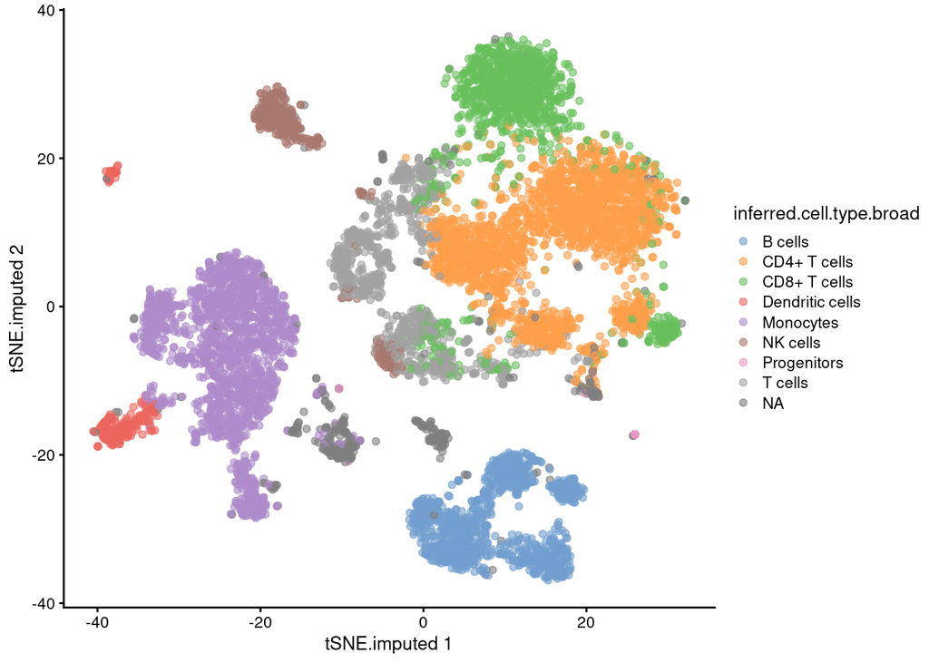

```r
colData(qc.out$sce)$inferred.cell.type.broad = pred.ct$pruned.labels[match(colnames(qc.out$sce),rownames(pred.ct))]

plotReducedDim(qc.out$sce,dimred = "tSNE.imputed",colour_by = "inferred.cell.type.broad")
```

```r
rm(hpca.se)
gc()
```

```
##             used   (Mb) gc trigger   (Mb)   max used    (Mb)
## Ncells   9265737  494.9   17784992  949.9   12358022   660.0
## Vcells 476020955 3631.8  941622255 7184.1 2211716566 16874.1
```

```r
# Conversion to Seurat object:Not necessary to run.
if (FALSE)
{
  library(Seurat)
  seu = CreateSeuratObject(counts = counts(qc.out$sce),project = "pbmc8k",meta.data = as.data.frame(colData(qc.out$sce)))
  seu[["RNA"]]@data = logcounts(qc.out$sce)
  seu[["RNA"]]@scale.data = assay(qc.out$sce,"ALRA.logcounts")

  # Create DimReduc and add to object
  xy = reducedDim(qc.out$sce,"PCA.imputed")
  seu[['PCA']] <- CreateDimReducObject(embeddings = xy, key = "PCA_", global = T, assay = "RNA")

  xy = reducedDim(qc.out$sce,"UMAP.imputed")
  seu[['UMAP']] <- CreateDimReducObject(embeddings = xy, key = "UMAP_", global = T, assay = "RNA")

  xy = reducedDim(qc.out$sce,"tSNE.imputed")
  seu[['tSNE']] <- CreateDimReducObject(embeddings = xy, key = "tSNE_", global = T, assay = "RNA")
  rm(xy)

  # save converted seurat object
  saveRDS(seu,file = paste0(out.dir,"/SEU.celltype_inferred.RDS"))
}
```

## Section 3. MSC workflow: Pearson’s correlation

MSC requires the log-normalized gene expression matrix across the variable genes as the primary input. For correlations, we also provide binarized count matrix where count.matrix[i,j] = 1 if there is a non-zero count for ith gene in jth cell, otherwise count.matrix[i,j] = 0. This binarized matrix will further serve to model the correlation as a function of shared gene expressions between two cells. This is because the similarity between two cells is often dictated by the number of shared expressed genes. This workflow can be extended to any other similarity metrics.

```r
min.size = min.cell

# Register cores
if (getDoParWorkers() == 1 & n.cores > 1 & !(n.cores == getDoParWorkers()))
{
  cl <- parallel::makeCluster(n.cores)
  registerDoParallel(cl)
}

# Use ALRA imputed data for correlation computation
gene.data = qc.out$gene.data.alra # variable gene stats
dat = subset(gene.data,bio > 0 & p.value < 0.05) # subset for variable genes
bcnt.alra = counts(qc.out$sce)[rownames(dat),] # binarized count matrix for variable genes
m.alra = as.matrix(assay(qc.out$sce,"ALRA.logcounts")[rownames(dat),]) # log-normalized matrix for variable genes
bcnt.alra[bcnt.alra > 1E-320] = 1

### Calculate LEN: Use pairwise Pearson's correlation for cell cell similarity. Note that dist.func = function(a, b) cor(a,b,method ="pearson") is used to calculate pairwise Pearson's correlation.
len.out = generate_cell_network.wt.loess(
  mat = m.alra,
  bcnt = bcnt.alra,
  dist.func = function(a, b) cor(a,b,method ="pearson"),
  is.decreasing = TRUE,
  n.cores = n.cores
);
```

```
## - #. jobs per node:2091
```

```
## - runtime to calculate LEN per node:
##    user  system elapsed
##   0.293   0.032  83.761
## - Check duplicates...
## processed:1000/50007=2%
## processed:2000/50007=4%
## processed:3000/50007=6%
## processed:4000/50007=8%
## processed:5000/50007=10%
## processed:6000/50007=12%
## processed:7000/50007=14%
## processed:8000/50007=16%
## processed:9000/50007=18%
## processed:10000/50007=20%
## processed:11000/50007=22%
## processed:12000/50007=24%
## processed:13000/50007=26%
## processed:14000/50007=28%
## processed:15000/50007=30%
## processed:16000/50007=32%
## processed:17000/50007=34%
## processed:18000/50007=36%
## processed:19000/50007=38%
## processed:20000/50007=40%
## processed:21000/50007=42%
## processed:22000/50007=44%
## processed:23000/50007=46%
## processed:24000/50007=48%
## processed:25000/50007=50%
## processed:26000/50007=52%
## processed:27000/50007=54%
## processed:28000/50007=56%
## processed:29000/50007=58%
## processed:30000/50007=60%
## processed:31000/50007=62%
## processed:32000/50007=64%
## processed:33000/50007=66%
## processed:34000/50007=68%
## processed:35000/50007=70%
## processed:36000/50007=72%
```

[output cut: 54 more lines]

```
## processed:40000/50007=80%
## processed:41000/50007=82%
## processed:42000/50007=84%
## processed:43000/50007=86%
## processed:44000/50007=88%
## processed:45000/50007=90%
## processed:46000/50007=92%
## processed:47000/50007=94%
## processed:48000/50007=96%
## processed:49000/50007=98%
## processed:50000/50007=100%
## - runtime to calculate mutual neighbor ratios:
##    user  system elapsed
##  58.022   0.260  58.283
## Checking relationship between shared neighbors and correlations...
```

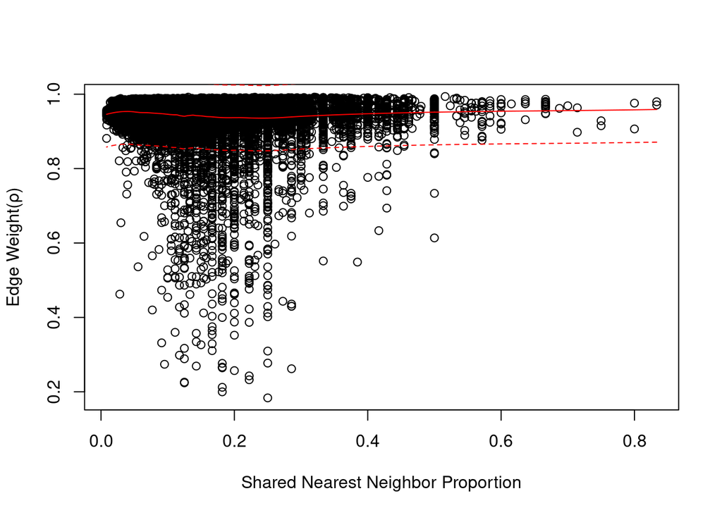

```
##
## FALSE  TRUE
## 41840   862
## Pruning low betweenness edges...
```

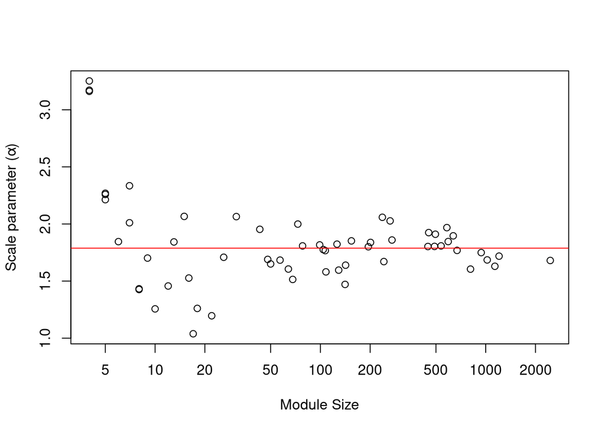

```
## Scale parameter:
## [1] 1.788194
```

```r
### Run iterative top-down clustering
d.func = function(x) sqrt(2*(1-x)) # use metric distance between the cells for correlations. The distance metric is used to calculate the cluster compactness

# identify alpha, the scaling parameter to calculate the cluster compactness
cout = components(len.out)
ci = which(cout$csize > log(vcount(len.out)))
glst = lapply(ci,function(n) induced_subgraph(graph = len.out,vids = names(cout$membership)[cout$membership == n]))

alpha.res = sapply(glst,function(gi) identify_scale_parameter(g = gi,nv = 20,nr.max = 3,seed = 1234,d.func = d.func,mode = "diameter"))[1]
```

```r
gc()
```

```
##             used   (Mb) gc trigger   (Mb)   max used    (Mb)
## Ncells   9270985  495.2   17784992  949.9   17784992   949.9
## Vcells 488539352 3727.3  941622255 7184.1 2211716566 16874.1
```

```r
# iterative clustering
iter.res = iterative_clustering(g.in = len.out,min.size = min.size,d.func = d.func,alpha = alpha.res)
```

```
## ##### Multiscale clustering iteration.1
##  - current number of identified modules:0
##  - number of parent modules to split:1
##  - parent module names:M0
## ##### Multiscale clustering iteration.2
##  - current number of identified modules:2
##  - number of parent modules to split:1
##  - parent module names:M1
## # Commence coarse-grained structure detection...
## Step detected...
## - clusters:
##   M3   M4   M5   M6   M7   M8
## 2183   61  384 3248 1131 1124
## - evaluate compactness with alpha = 1.78819411526898
## - evaluate intra-cluster connectivity
## -- Check random connectivity for controls...
## # Collect results
## ##### Multiscale clustering iteration.3
##  - current number of identified modules:8
##  - number of parent modules to split:6
##  - parent module names:M3,M4,M5,M6,M7,M8
## # Commence coarse-grained structure detection...
## Step detected...
## - clusters:
##  M9 M10 M11 M12 M13 M14
## 856 476 217 168 226 240
## - evaluate compactness with alpha = 1.78819411526898
## - evaluate intra-cluster connectivity
## -- Check random connectivity for controls...
## # Collect results
## # Commence coarse-grained structure detection...
## Step detected...
## - clusters:
## M15 M16 M17
##  35  15  11
## - evaluate compactness with alpha = 1.78819411526898
## - evaluate intra-cluster connectivity
## -- Check random connectivity for controls...
## # Collect results
## # Commence coarse-grained structure detection...
```

[output cut: 296 more lines]

```
## M86 M87 M88
##  12   5   3
## - evaluate compactness with alpha = 1.78819411526898
## - evaluate intra-cluster connectivity
## -- Check random connectivity for controls...
## # Collect results
## # Commence coarse-grained structure detection...
## Step detected...
## - clusters:
## M89 M90
## 359 432
## - evaluate compactness with alpha = 1.78819411526898
## - evaluate intra-cluster connectivity
## -- Check random connectivity for controls...
## # Collect results
```

```r
# probe cluster hierarchy to identify the main root cluster.
do.probe = TRUE
mo = "M0"
while (do.probe)
{
  tbl = subset(iter.res$module.table,parent.cluster == mo & module.size >= min.cells)
  if (nrow(tbl) > 1)
  {
    do.probe = FALSE
  }else{
    mo = tbl$cluster.name[1]
  }
}
iter.res$root.cluster = mo

#saveRDS(iter.res,file = paste0(out.dir,"/MSC_Pearson.RDS"))

iter.res.cor = iter.res;
rm(iter.res)
```

## Section 4. MSC workflow: Euclidean distances

In contrary to Section 3, we use Euclidean distance in PCA space to perform MSC. Since PCA-based calculation does not directly utilize the expression matrix across all genes, the binarized count matrix is not necessary for down-stream analysis. Again, this workflow can be extended to any other dissimilarity metrics.

```
## - #. jobs per node:2091
```

```
## - runtime:
##    user  system elapsed
##   0.032   0.012  97.321
## - Check duplicates...
## processed:1000/37494=2.67%
## processed:2000/37494=5.33%
## processed:3000/37494=8%
## processed:4000/37494=10.7%
## processed:5000/37494=13.3%
## processed:6000/37494=16%
## processed:7000/37494=18.7%
## processed:8000/37494=21.3%
## processed:9000/37494=24%
## processed:10000/37494=26.7%
## processed:11000/37494=29.3%
## processed:12000/37494=32%
## processed:13000/37494=34.7%
## processed:14000/37494=37.3%
## processed:15000/37494=40%
## processed:16000/37494=42.7%
## processed:17000/37494=45.3%
## processed:18000/37494=48%
## processed:19000/37494=50.7%
## processed:20000/37494=53.3%
## processed:21000/37494=56%
## processed:22000/37494=58.7%
## processed:23000/37494=61.3%
## processed:24000/37494=64%
## processed:25000/37494=66.7%
## processed:26000/37494=69.3%
## processed:27000/37494=72%
## processed:28000/37494=74.7%
## processed:29000/37494=77.3%
## processed:30000/37494=80%
## processed:31000/37494=82.7%
## processed:32000/37494=85.3%
## processed:33000/37494=88%
## processed:34000/37494=90.7%
## processed:35000/37494=93.3%
## processed:36000/37494=96%
```

[output cut: 25 more lines]

```
## processed:24000/37494=64%
## processed:25000/37494=66.7%
## processed:26000/37494=69.3%
## processed:27000/37494=72%
## processed:28000/37494=74.7%
## processed:29000/37494=77.3%
## processed:30000/37494=80%
## processed:31000/37494=82.7%
## processed:32000/37494=85.3%
## processed:33000/37494=88%
## processed:34000/37494=90.7%
## processed:35000/37494=93.3%
## processed:36000/37494=96%
## processed:37000/37494=98.7%
## Checking relationship between shared neighbors and correlations...
```

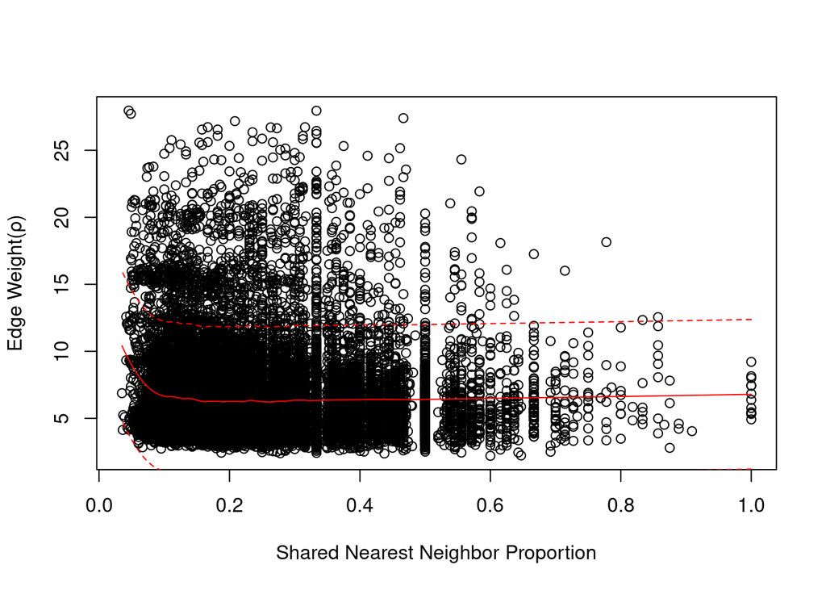

```
##
## FALSE  TRUE
## 30942  1438
## Pruning low betweenness edges...
```

```r
min.size = min.cell

# Register cores
if (getDoParWorkers() == 1 & n.cores > 1 & !(n.cores == getDoParWorkers()))
{
  cl <- parallel::makeCluster(n.cores)
  registerDoParallel(cl)
}

# get PCA as the imput
mat = as.matrix(t(reducedDim(qc.out$sce,"PCA.imputed")))

# Calculate LEN: Use pairwise Euclidean distance in PCA space for cell cell similarity. Note that dist.func = function(x,y) sqrt(sum((x-y)^2)) is used with is.decreasing = FALSE to sort the cell pairs from short distances to longer distances.
len.out = generate_cell_network.wt.loess(
  mat,
  bcnt = NULL,
  dist.func = function(x,y) sqrt(sum((x-y)^2)),
  is.decreasing = FALSE,
  n.cores = 4
);
```

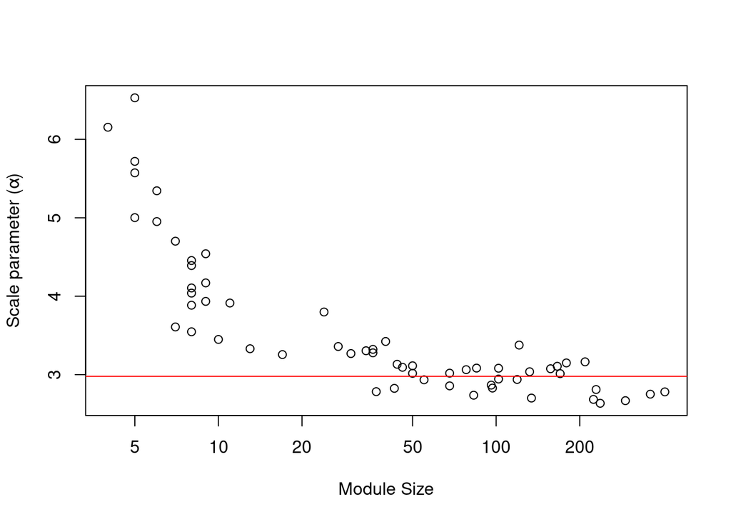

```
## Scale parameter:
## [1] 2.978133
```

```r
# run iterative top-down clusters
d.func = function(x) x # the pairwise distance is passed onto the LEN network by identity function, f(x) = x.

cout = components(len.out)
ci = which(cout$csize > log(vcount(len.out)))
glst = lapply(ci,function(n) induced_subgraph(graph = len.out,vids = names(cout$membership)[cout$membership == n]))

alpha.res = sapply(glst,function(gi) identify_scale_parameter(g = gi,nv = 20,nr.max = 3,seed = 1234,d.func = d.func,mode = "diameter"))[1]
```

```r
gc()
```

```
##             used   (Mb) gc trigger   (Mb)   max used    (Mb)
## Ncells   9300347  496.7   17784992  949.9   17784992   949.9
## Vcells 488936144 3730.3  941622255 7184.1 2211716566 16874.1
```

```r
# run MSC
iter.res = iterative_clustering(g.in = len.out,min.size = min.size,d.func = d.func,alpha = alpha.res)
```

```
## ##### Multiscale clustering iteration.1
##  - current number of identified modules:0
##  - number of parent modules to split:1
##  - parent module names:M0
## # Commence coarse-grained structure detection...
## Step detected...
## - clusters:
##   M1   M2   M3   M4   M5   M6   M7   M8   M9
##  296 1724 1245 1158  286 2021 1135   97  222
## - evaluate compactness with alpha = 2.97813324728707
## - evaluate intra-cluster connectivity
## -- Check random connectivity for controls...
## # Collect results
## ##### Multiscale clustering iteration.2
##  - current number of identified modules:9
##  - number of parent modules to split:7
##  - parent module names:M1,M2,M3,M5,M6,M7,M9
## # Commence coarse-grained structure detection...
## Step detected...
## - clusters:
## M10 M11 M12
##  62 123 111
## - evaluate compactness with alpha = 2.97813324728707
## - evaluate intra-cluster connectivity
## -- Check random connectivity for controls...
## # Collect results
## # Commence coarse-grained structure detection...
## Step detected...
## - clusters:
## M13 M14 M15 M16 M17
## 181 776 253  22 492
## - evaluate compactness with alpha = 2.97813324728707
## - evaluate intra-cluster connectivity
## -- Check random connectivity for controls...
## # Collect results
## # Commence coarse-grained structure detection...
## Step detected...
## - clusters:
## M18 M19 M20 M21
## 277 676   9 283
```

[output cut: 141 more lines]

```
## M56 M57 M58
##  46  34  28
## - evaluate compactness with alpha = 2.97813324728707
## - evaluate intra-cluster connectivity
## -- Check random connectivity for controls...
## # Collect results
## # Commence coarse-grained structure detection...
## Step detected...
## - clusters:
## M59 M60 M61 M62
## 143 142  27  72
## - evaluate compactness with alpha = 2.97813324728707
## - evaluate intra-cluster connectivity
## -- Check random connectivity for controls...
## # Collect results
```

```r
# probe cluster hierarchy to identify the main root cluster.
do.probe = TRUE
mo = "M0"
while (do.probe)
{
  tbl = subset(iter.res$module.table,parent.cluster == mo & module.size >= min.cells)
  if (nrow(tbl) > 1)
  {
    do.probe = FALSE
  }else{
    mo = tbl$cluster.name[1]
  }
}
iter.res$root.cluster = mo

#saveRDS(iter.res,file = paste0(out.dir,"/MSC_Euclidean.RDS"))

iter.res.euc = iter.res;
rm(iter.res)
```

## Section 5. Hierarchical visualization of markers

The cluster hierarchy has been integrated with the dotplot to show the marker expression architecture.

```r
##### established markers: We
# get the markers
ct.markers = c("T-cell" = "CD3D","CD4" = "CD4","CD8" = "CD8A","CD8" = "NKG7",
               "effector CD8" = "IFNG",
               "Treg" = "FOXP3","Treg" = "IL2RA",
               "B-cell" = "CD19","Monocyte" = "CD14",
               "M1" = "HLA-DRA","M2" = "MSR1","MDSC" = "S100A9",
               "Dendritic" = "NRP1",
               "NK" = "NCAM1","Erythrocyte" = "HBA1","Platelet" = "PF4")
ct.markers.mapped = rownames(qc.out$sce)[match(ct.markers,gsub("\\|(.*)$","",rownames(qc.out$sce)))];
names(ct.markers.mapped) = names(ct.markers);

### get the plot
cnt = counts(qc.out$sce)
mat = assay(qc.out$sce,"ALRA.logcounts")
rownames(cnt) = rownames(mat)
htbl = iter.res.cor$module.table[,c("cluster.name","parent.cluster")];colnames(htbl) = c("module.id","module.parent")
modules = iter.res.cor$modules
hplot.out = plot_hierarchy_dot.raw(m = mat,cnts = cnt,
                                   htbl,modules,celltype.markers = ct.markers.mapped,pct.mark = 0.1,
                                   plot.hierarchy = TRUE,
                                   filename = "pbmc_8k/hierarchy.celltype.png",width.per.plot = 500,height.per.plot = 3500)
```

```
## Calculate marker statistics...
## Plotting the hierarchy with dots...
## output plots to:pbmc_8k/hierarchy.celltype.png
```

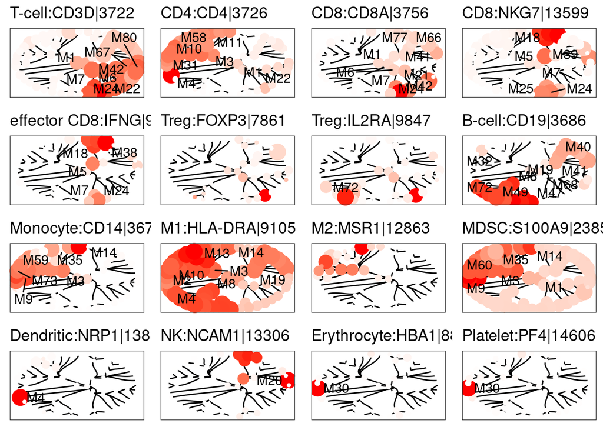

```r
plot_grid(plotlist = lapply(hplot.out$plotlist,function(x) x + theme(legend.position = "none")),ncol = 4)
```

## Section 6. Visualize MSC results using various tools

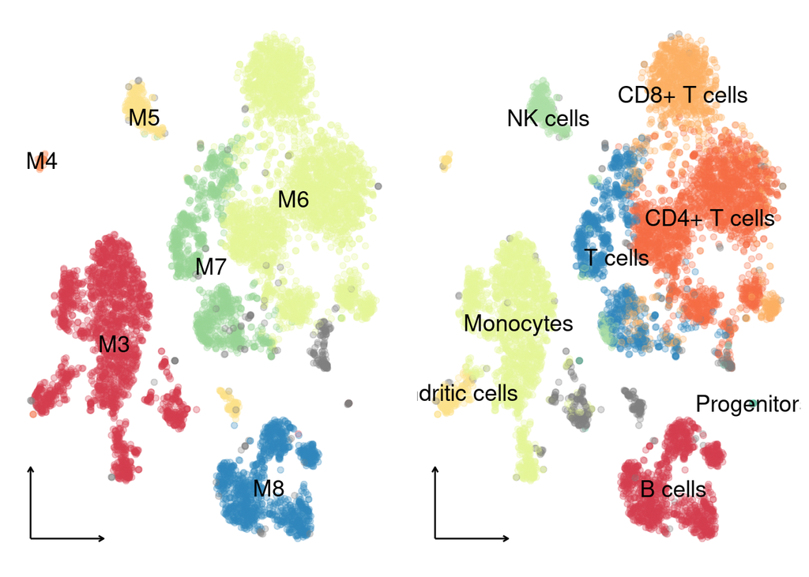

```r
### get embedding coordinates
xy = reducedDim(qc.out$sce,"tSNE.imputed")
xy = xy[colnames(qc.out$sce),]

### clustering results
# get the membership rooted to certain parent module
vec = get_rooted_membership(mtbl = iter.res.cor$module.table,
                            modules = iter.res.cor$modules,
                            pid = iter.res.cor$root.cluster,bg = colnames(qc.out$sce))

pobj.msc = plot_dimred_manual.raw(xy,
                                  cell.feat = vec,
                                  alpha.val = 0.3,cls.col = NULL,add.labels = TRUE)

# add other aesthetic features
pobj.msc = pobj.msc +
guides(colour = "none") +
  theme_classic() +
  theme(axis.line = element_blank(),axis.title = element_blank(),axis.text = element_blank(),axis.ticks = element_blank()) +
  annotate(geom = "segment",x = quantile(xy[,1],0),xend = quantile(xy[,1],0.1),y = min(xy[,2]),yend = min(xy[,2]),colour = "black",arrow = grid::arrow(length = unit(0.015, "npc"))) +
  annotate(geom = "segment",x = min(xy[,1]),xend = min(xy[,1]),y = min(xy[,2]),yend = quantile(xy[,2],0.1),colour = "black",arrow = grid::arrow(length = unit(0.015, "npc")) )

### get cell type tSNE plots
vec = colData(qc.out$sce)$inferred.cell.type.broad;names(vec) = colnames(qc.out$sce)
pobj.ct.broad = plot_dimred_manual.raw(xy,cell.feat =vec,alpha.val = 0.3,cls.col = NULL,add.labels = TRUE) + guides(colour = "none") +
  theme_classic() +
  theme(axis.line = element_blank(),axis.title = element_blank(),axis.text = element_blank(),axis.ticks = element_blank()) +
  annotate(geom = "segment",x = quantile(xy[,1],0),xend = quantile(xy[,1],0.1),y = min(xy[,2]),yend = min(xy[,2]),colour = "black",arrow = grid::arrow(length = unit(0.015, "npc"))) +
  annotate(geom = "segment",x = min(xy[,1]),xend = min(xy[,1]),y = min(xy[,2]),yend = quantile(xy[,2],0.1),colour = "black",arrow = grid::arrow(length = unit(0.015, "npc")) )

library(cowplot)
print(plot_grid(pobj.msc,pobj.ct.broad,ncol = 2))
```

## Section 7. Hierarchical cluster respresentation with piecharts

The multi-scale clustering architecture in MSC can be effectively represented as a hierarchical dendrogram. Here, we make use of this hierarchy to visualize the cell cluster characteristic by pie charts at different hierarchical levels, allowing to inspect the relationship between the hierarchy and cell cluster features.

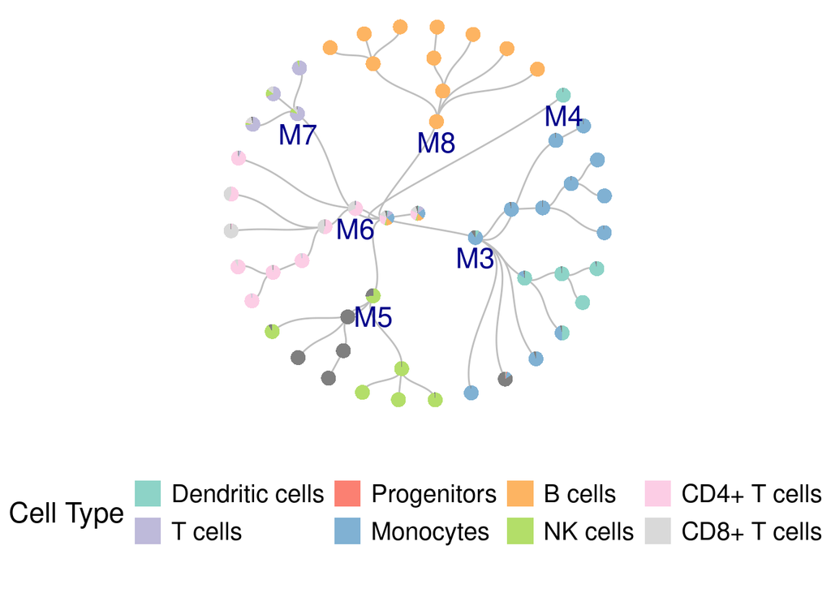

```r
library(RColorBrewer)

# assign cell type colors
vec.ct = colData(qc.out$sce)$inferred.cell.type.broad;names(vec.ct) = colnames(qc.out$sce);
ct = unique(vec.ct)
colmap.ct = brewer.pal(n = length(ct),"Set3")
names(colmap.ct) = ct

# get cluster hierarchy
htbl = subset(iter.res.cor$module.table,module.size >= 30)[,c("cluster.name","parent.cluster")]
modules = iter.res.cor$modules

# make piechart
pie.ct = plot_hierarchy_pie(htbl,modules,vec.ct,colmap = colmap.ct,edge_colour = "grey")
pie.ct = pie.ct + guides(fill = guide_legend(label.theme = element_text(size = 15),title.theme = element_text(size = 17),title = "Cell Type"))

# extract legend
library(ggpubr)
leg = get_legend(pie.ct)
leg = as_ggplot(leg)

txt.dat = pie.ct$data[,c("x","y","name")]
txt.dat = subset(txt.dat,name %in% c(subset(iter.res.cor$module.table,parent.cluster == "M1")$cluster.name))
library(ggrepel)
pie.ct = pie.ct + geom_text_repel(data = txt.dat,aes(x = x,y = y,label = name),colour = "darkblue",segment.colour = "darkblue",vjust = 1.5,size = 6) +
  guides(fill = "none") +
  theme(panel.border = element_blank(),legend.position = "right",legend.direction = "vertical",
        legend.text = element_text(size = 16),
        plot.title = element_text(size = 20,hjust = 0.5),
        plot.margin = margin(t = 0,r = 0,b = 0,l = 0))
pie.ct = plot_grid(pie.ct,leg,ncol = 1,rel_heights = c(0.8,0.3))

print(pie.ct)
```